# Big Fish in Small (and Big) Ponds: A Study of Careers | The Journal of Law, Economics, and Organization | Oxford Academic

### 3.2 Characterization of the Symmetric Equilibria

Since all firms have the same production technology, it is unsurprising that a symmetric equilibrium can exist in which they all make the same period-1 wage offers and use the same promotion rule. Given the assumption that firms wish to promote workers who are revealed to have high ability, two such equilibria can exist. They are presented in the following Propositions 1 and 2.

Before turning to these propositions, we briefly explain how decisions are made in our model and which conditions must be fulfilled in equilibrium. In period 2, the incumbent firm always matches the highest offer by the external firms, meaning that it will always retain the worker unless it mistakenly fails to make a counteroffer. The external firms, anticipating this reaction, thus compete in regular Bertrand fashion and their highest offer equals the output that they expect the worker to produce. This output depends on the external firms’ expectation of the worker’s ability which, in turn, depends on whether or not the worker was promoted and the (promotion) strategy that the external firms believe the incumbent to play (and which they correctly infer in equilibrium).

The incumbent firm promotes the worker if and only if the profit (i.e., output minus wage) from promotion is higher than the profit from reassigning the worker to the low-level job. Both output and wage are typically larger in the high-level job than in the low-level job so that the firm needs to trade off the larger output and the larger wage when making the promotion decision.<sup>8</sup> Finally, in period 1, firms again compete in Bertrand fashion, implying that all rents accrue to the workers. Workers’ selection of firms is not an issue in the symmetric equilibria and we elaborate on it when presenting the asymmetric equilibrium in the next subsection.

In the symmetric pooling equilibrium described in Proposition 1, all firms use loose promotion rules, promoting all workers regardless of their abilities.

Proposition 1

Proofs of all propositions are in Appendix A and contain the expressions for equilibrium wages and the parameter constellations for which the equilibria exist. In all propositions, references to “all firms” making a particular period-2 wage offer have the caveat that there is a (small) probability that the incumbent firm mistakenly fails to make a counteroffer.

The symmetric pooling equilibrium described in Proposition 1 always exists whenever *S* is sufficiently large, meaning when firm-specific human capital is sufficiently important. The reason is that external firms’ wage offers do not depend on *S*, because firm-specific human capital is lost when a worker switches firms. A worker’s current employer bases the wage offer on the external firms’ offers, so the current employer’s offer does not depend on *S* either. Moreover, the worker’s productivity advantage in job 2 compared with job 1 is increasing without bound in *S*. Therefore, whenever *S* is high enough, all firms always wish to promote all of their workers independent of their abilities. The equilibrium described in Proposition 1 maximizes welfare for the following reason. Having worked in job 1 in period 1, workers are always more productive in job 2 than in job 1. Hence, the overall surplus is maximized when all workers are assigned to job 2 in period 2. Proposition 1 could be interpreted as describing a seniority-based promotion system, as discussed in Section 5.

It is instructive to relate our results to those of Rothschild and Stiglitz (1976). They model a competitive insurance market, where customers are either good or bad risks (i.e., they have low or high probability of causing damage) and they are privately informed about their type. Rothschild and Stiglitz (1976) show that a pooling equilibrium in which both types of customers are offered the same insurance contract does not exist. The intuition is that firms can make a profit by deviating and offering an alternative contract that is only attractive to the good-risk customers.

Transferring their intuition to our model, one might conjecture that a pooling equilibrium does not exist either, since firms have an incentive to deviate by offering contracts that only appeal to the workers observing a positive signal about their ability. Such a contract would need to stipulate a relatively lower promotion probability in case a worker has low ability, since changing the promotion decision is the only possible way to separate worker types.

There are two important differences between our model and that of Rothschild and Stiglitz (1976). First, in their model firms can commit to insurance contracts, whereas they cannot commit to promotion rules in ours. This means that firms cannot deviate by claiming that they are not going to promote low-ability workers if it is actually optimal for firms to promote these workers. Second, the insurance contracts studied by Rothschild and Stiglitz (1976) are continuous in the sense that the payments that customers receive can be continuously varied. In our model, in contrast, the promotion decision is discrete. As a consequence of the preceding two differences, the aforementioned deviation is not possible in our model. Thus, a pooling equilibrium can exist.

If we were to adopt their assumptions by allowing firms to commit to continuous promotion rules (i.e., rules that allow workers to be promoted with certain pre-specified probabilities), then the pooling equilibrium described in the preceding proposition would fail to exist. The reason is that, under these assumptions, firms would indeed be able to offer alternative contracts that are only attractive to the workers observing positive signals about their abilities, meaning that a deviation to such an alternative contract is beneficial.

The next proposition shows that inefficient equilibria can also exist. In the forthcoming equilibrium, promotion rules are more stringent than in the preceding equilibrium, meaning that only high-ability workers are promoted. Therefore, a worker’s period-2 job assignment always reveals the worker’s ability to all firms. Consequently, promoted workers’ wages are higher than those of non-promoted workers, which, as in Waldman (1984), makes it optimal for the firms to set an inefficiently high promotion standard. Existence of a symmetric separating equilibrium in which only high-ability workers are promoted requires that *S* not be too large given that, as stated in the discussion following Proposition 1, if *S* is sufficiently large, firms wish to promote all workers, regardless of their abilities.

Proposition 2

### 3.3 Characterization of the Asymmetric “Fish-and-Ponds” Equilibrium

Within each of the preceding two symmetric equilibria, all firms behave identically, so that workers’ self-selection into firms does not play a role. Self-selection becomes relevant only if firms differ in their decisions and workers then select a firm that offers the highest expected lifetime earnings (i.e., the sum of the period-1 wage and the expected period-2 wage). Interestingly, even though all firms have the same production technology, asymmetric equilibria potentially exist. In particular, it is possible that some firms (i.e., big ponds) select stringent promotion rules, promoting only workers who are revealed to have high ability, whereas other firms (i.e., small ponds) promote all workers regardless of their ability. The following proposition characterizes the corresponding asymmetric separating fish-and-ponds equilibrium.

Proposition 3

In the fish-and-ponds equilibrium, a firm is defined as a small pond if it chooses to promote workers regardless of their abilities, whereas a firm is a big pond if it promotes only those workers who are revealed to have high ability. Pond size is defined in terms of unconditional promotion probabilities, meaning that a small pond has a high unconditional probability of promotion and a big pond has a low unconditional probability of promotion. An alternative definition of pond size would condition on ability. That is, holding worker type/ability fixed, a small pond has a larger promotion probability, and a large pond has a smaller probability. This alternative (conditional) definition applies in the preceding fish-and-ponds equilibrium, albeit only weakly. In the equilibrium, the condition is true for low-ability workers, because those workers are never promoted in the big pond but are always promoted in the small pond. High-ability workers are always promoted in either pond, so their promotion probabilities are the same. Thus, conditional on ability, the overall promotion probability is weakly lower in the big than in the small pond. Moreover, when conditioning on the ability signals rather than on their realizations, the inequalities are strict for both signals.

An implication is that ponds are signals. Choosing a big pond allows workers to signal high ability in two ways. First, only workers with a favorable ability signal select a big pond and this is reflected in period-1 wages, as discussed below. Second, only those workers who are revealed to have high ability will be promoted. Consequently, big ponds pay higher period-2 wages than small ponds (in job 2). The respective wages in job 1 cannot be compared across ponds, because in a small pond, all workers are promoted in equilibrium. As discussed at the start of Section 4, however, the model could be extended to allow for an additional ability level for which it would be inefficient to promote a worker. In that case, a small pond would be a firm in which workers are promoted unless they have the lowest ability, whereas a big pond would be a firm in which only the workers of the highest ability are promoted.

In the fish-and-ponds equilibrium of Proposition 3, the selection of workers into firms is determined by worker choices. In certain real-world settings, however, employer screening and selection are likely to be important. For example, many MBAs want to work for the two big-pond consulting firms, McKinsey and Bain, which allows those firms to be highly selective. Employer screening and selection is a relevant consideration that should be explored in future work. Nonetheless, analysis of the ponds phenomenon from the standpoint of worker choice is still enlightening, even in the preceding example. While the yield rate on job offers extended by big-pond consulting firms is surely high, it is not 100%; some workers turn those offers down if they prefer a less competitive working environment where their chances of standing out and advancing quickly within the firm are higher. Moreover, the observed yield rate is inflated because there are some talented MBAs who could successfully compete for jobs at Bain or McKinsey but who select out by not even applying. We view worker self-selection into firms as an important aspect of the ponds phenomenon even if it cannot account for it entirely.

Turning next to equilibrium existence, the first question is whether pure-strategy equilibria exist that exhibit promotion rules that differ from the three identified in the preceding propositions. The answer is no, as long as it is assumed that firms treat workers with identical output realizations the same way by holding them to the same promotion rule.<sup>9</sup> One qualification should be noted, however. Given that firms make zero profits in equilibrium, alternative pure-strategy equilibria may exist in which some firms make lower wage offers and never hire any workers, while the remaining firms make the same offers as in the present model. But in that case the outcomes concerning equilibrium job assignments and wages would be unchanged even if some firms play different strategies, so from an empirical standpoint such equilibria would look identical to those presented.<sup>10</sup>

The following corollary to Propositions 1–3 relates the existence of the fish-and-ponds equilibrium to that of the stringent and loose equilibria.

*Corollary 1*. The existence of the fish-and-ponds equilibrium implies the existence of the stringent equilibrium, whereas it does not imply the existence of the loose equilibrium.

Whenever the fish-and-ponds equilibrium exists, the stringent equilibrium also exists.<sup>11</sup> The intuition is that, upon learning workers’ abilities at the end of period 1, the big-pond firms in the fish-and-ponds equilibrium face the same decision problem as the firms in the stringent equilibrium. The same is not true of the loose equilibrium, so that the fish-and-pond equilibrium can exist absent the loose equilibrium.

Existence of the stringent equilibrium, however, does not imply the existence of the fish-and-ponds equilibrium. The reason is that additional conditions are needed to ensure that workers self-select into ponds. These conditions require that *λ* not be too high. For workers who receive an unfavorable ability signal, the benefit from selecting a small pond is that every worker gets promoted, so that workers’ possibly low ability is not revealed to the market. If *λ* approaches 1, however, this benefit disappears, because workers would then essentially reveal their low ability by selecting the small pond. In this case, workers receiving a negative signal about their ability would always deviate from the proposed equilibrium by selecting a big pond.

The preceding discussion implies that multiple equilibria are possible for a given set of parameter values. An equilibrium refinement is applied to resolve multiple equilibria for the regions of the parameter space in which they occur. Specifically, efficiency is used as an equilibrium selection criterion. The idea is that if a more rather than a less efficient equilibrium is played, then additional surplus is created, which could be allocated among the players so as to make everyone better off. Therefore, using efficiency as a selection criterion is closely related to the well-known concept of payoff dominance (Harsanyi and Selten 1988).

Two standard and popular equilibrium refinements might be considered as alternatives to the preceding efficiency refinement, though neither are helpful in this model. The first is the intuitive criterion, proposed by Cho and Kreps (1987).<sup>12</sup> The second is coalition proofness (Bernheim et al. 1987). A formal analysis of this refinement is not pursued because it would be prohibitively complex, given that a large number of potential coalitions is possible. Nonetheless, the fish-and-ponds equilibrium appears not to be coalition proof and neither is the stringent equilibrium that (by the preceding corollary) always appears alongside it.<sup>13</sup> Therefore, coalition proofness cannot be used to rank these two equilibria.

The fact that the fish-and-ponds equilibrium is never unique (because it always exists alongside the stringent equilibrium) raises the question of why many real-world settings appear to exhibit the fish-and-ponds phenomenon. This can be answered in two ways. First, as noted, using efficiency as an equilibrium refinement implies that the fish-and-ponds equilibrium will be chosen over the stringent equilibrium. The refinement is most applicable in settings in which the players can communicate and use that communication to coordinate on the efficient equilibrium. Although direct communication will not always be possible in every setting, tacit communication should often be possible in the Internet age in which there is voluminous publicly available information posted to and by employers and workers. Second, although the model assumes that firms are ex ante identical, in reality there could be firm heterogeneity for pre-determined reasons. If in the high-level job there is production function heterogeneity in the sensitivity of workers’ outputs to their abilities, then the fish-and-ponds equilibrium can be unique. Footnote 11 elaborates.

### 3.4 Analysis of Equilibrium Existence Conditions

Many parameters affect the existence and coexistence of the three equilibria and it is not possible to unambiguously determine which equilibria coexist when a given parameter is continuously varied while the others remain fixed. Nonetheless, some progress is possible. The loose equilibrium exists and is unique when the parameter configurations are such that workers are much more productive in job 2 than in job 1, so that firms greatly benefit from promoting workers. In contrast, the stringent equilibrium exists and is unique for parameter configurations such that the productivity gain from promotion is relatively low. Finally, when the productivity gain from promotion is intermediate, other possibilities arise, but the fish-and-ponds equilibrium can never exist alone, nor can it coexist with the loose equilibrium but absent the stringent equilibrium. Moreover, all three equilibria can simultaneously coexist. It is also possible that the two symmetric equilibria exist in the absence of the fish-and-ponds equilibrium. Recall, however, that a unique equilibrium results when efficiency is applied as a refinement.

Graphical representations of how existence changes across different regions of the parameter space are enlightening. For example, Figure 2 varies *S* and *λ* simultaneously, holding all others fixed at particular values.

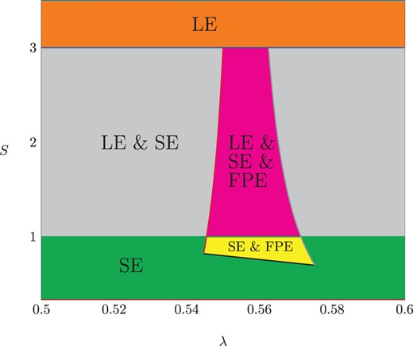

Figure 2.

The fish-and-ponds equilibrium exists only if both *S* and *λ* are neither too small nor too large. If *S* is large, then the gain from promoting a worker is so high that the big-pond firms wish to deviate by promoting all of their workers. Similarly, if *S* is low, the small-pond firms have an incentive to deviate by reassigning their low-ability workers to job 1 rather than promoting these workers. If *λ* is relatively high, then the big-pond firms are relatively confident of hiring high-ability workers and, thus, offer high wages to their workers. Here, the workers receiving the unfavorable ability signal wish to deviate by joining a big-pond firm instead of a small-pond firm. If *λ* is very low, big-pond firms are not very confident of hiring high-ability workers, so that the corresponding wages are low. Now the workers observing a favorable ability signal find it beneficial to deviate by joining a small-pond firm.

The conditions necessary for the fish-and-ponds equilibrium to exist are considerably more expansive when the baseline model is extended to incorporate workers’ overconfidence about their abilities, as shown in the next section.

## 4. Extensions

Two extensions of the baseline model are presented formally, in Sections 4.1 and 4.2. Three others are briefly and informally summarized beforehand, with elaboration and formal analyses available upon request. First, the simplifying assumption of binary ability from the baseline model implies, unrealistically, that all workers in small ponds get promoted in equilibrium. If a third “very low” ability level is introduced, along with three possible values for the ability signal that workers receive, then for some parameter configurations a fish-and-ponds equilibrium exists with similar properties to those of the baseline model, but in which the lowest-ability workers are not promoted, even in small ponds. Then the fact that non-promoted workers exist in both types of ponds means that period-2 wages can be compared in both job levels and are always higher in big than in small ponds.

Second, after period-1 wage offers are made and workers join firms, the workers can make costly investments in their general human capital. A worker whose initial ability is low could still achieve high ability due to the investment and this happens with some constant probability. The investment is undertaken during period 1 and, thus, affects only period-2 output. Apart from this difference in the timing of when these human capital investments yield productivity returns, they can be thought of as effort choices. As in the baseline model’s equilibrium, workers who receive the low ability signal choose a small pond, whereas those receiving the high ability signal choose a big pond. Workers who join a small pond never make human capital investments, whereas those who join a big pond invest when the cost of doing so is sufficiently low. Those investments increase the likelihood of a promotion and the accompanying wage increase.

Third, workers’ preferences for promotion are incorporated into the model to reflect the fact that workers’ desire to get promoted sometimes extends beyond the wage increases that are expected to accompany promotion. This extension creates the possibility that a worker who has sufficiently strong preferences for getting promoted might choose the small pond even when receiving a high ability signal. Although symmetric equilibria also exist, all of the extensions exhibit an asymmetric equilibrium in which big and small ponds coexist and the different types of firms target different types of workers.

### 4.1 A Constraint on the Number of Managers

Proposition 4

> (iii) When worker *j* is hired by some big-pond firm , this firm promotes the worker at the end of period 1 if and only if *a*<sub>j</sub> = *a*<sub>H</sub>.